# Techniki wizualizacji danych - zadanie domowe 5

Dawid Stelmach

12 listopada 2017

Źródło danych:

- https://www.bankier.pl/wiadomosc/Juz-2-mln-klientow-porzucilo-bankowosc-internetowa-na-rzecz-mobilnej-7554978.html

Dane, które zdecydowałem się opracować, dotyczą liczby użytkowników mobilnych w bankach będących na polskim rynku. Użytkownicy zostali oni podzieleni na dwie grupy:

- ‘’aplikacje’’ - użytkownicy, którzy korzystają z aplikacji mobilnych
- ‘’inne’’ - użytkownicy korzystający z innego sposobu dostępu do usług bankowych niż dedykowane aplikacje banku.

Ponadto został obliczony procentowy udział użytkowników korzystających z aplikacji z podziałem na bank.

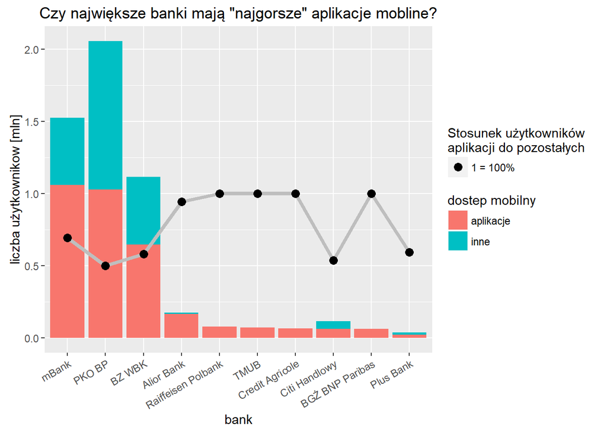

Jak widać, banki ze środka stawki mają, najwyższy wskaźnik użytkowników korzystających z aplikacji. Może być to spowodowane tych, że ich aplikacje są istotnie najlepsze i osoby wybrały te banki właśnie ze względu na aplikacje mobilne. Już na pierwszy rzut oka widać, największe banki mają znacznie mniejszy udział użytkowników aplikacji. Należy pamiętać, że bierzemy pod uwagę tylko klientów mobilnych, a nie wszystkich klientów banków dlatego ta sytuacja nie ma związku z faktem, że popularne banki mają większą liczbę użytkowników niekorzystających z dobrodziejstw mobilnych technologii.